# SQL statements

November 12, 2025

Jo Hardin

# Agenda 11/12/25

1. structure of **SQL** tables
2. **SQL** keywords
3. **SQL** queries to **R** objects

# Today’s example

## Traffic Stops

Consider a database of information from [Stanford Open Policing Project](https://openpolicing.stanford.edu/data/) on over 200 million traffic stops in the US.

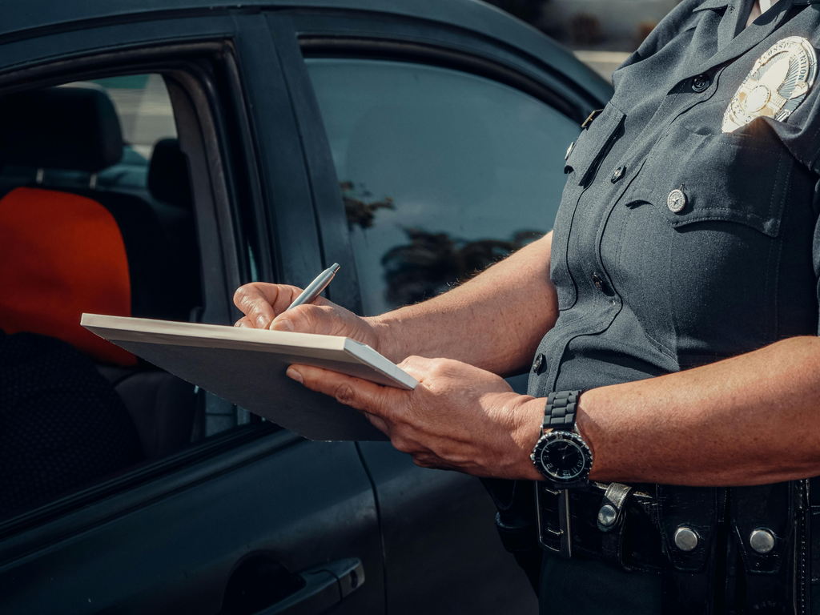

Photo by Kindel Media from Pexels: https://www.pexels.com/photo/police-officer-standing-next-to-the-gray-car-7715104/

## Establishing a SQL connection

```r
Sys.setenv(MARIADB_TLS_DISABLE_PEER_VERIFICATION = 1)

con_traffic <- DBI::dbConnect(
  RMariaDB::MariaDB(),
  dbname = "traffic",
  host = "traffic.st47s.com",
  user = Sys.getenv("TRAFFIC_USER"),
  password = Sys.getenv("TRAFFIC_PWD")
)
```

## Traffic Stops

88 tables in the `traffic` database! Lots of details on traffic stops across cities and highway patrols.

```sql
SHOW TABLES;
```

Displaying records 1 - 10

| Tables_in_traffic |
| --- |
| ar_little_rock_2020_04_01 |
| az_gilbert_2020_04_01 |
| az_mesa_2023_01_26 |
| az_statewide_2020_04_01 |
| ca_anaheim_2020_04_01 |
| ca_bakersfield_2020_04_01 |
| ca_long_beach_2020_04_01 |
| ca_los_angeles_2020_04_01 |
| ca_oakland_2020_04_01 |
| ca_san_bernardino_2020_04_01 |

## LAPD - glance through tables

(`0` is the number of rows that are skipped, `10` is the number of rows that are retrieved.)

```sql
SELECT *
FROM ca_los_angeles_2020_04_01
LIMIT 0, 10;
```

Displaying records 1 - 10

| raw_row_number | date | time | district | region | subject_race | subject_sex | officer_id_hash | type | raw_descent_description |
| --- | --- | --- | --- | --- | --- | --- | --- | --- | --- |
| 5692933 |  | 13:59:00 | 0753 | WILSHIRE | hispanic | male | 15ecd81b00 | pedestrian | HISPANIC |
| 240731 | 2010-01-01 | 00:05:00 | 665 | WEST TRAFFIC | other | male | b707de41e0 | vehicular | OTHER |
| 240592\|240593 | 2010-01-01 | 00:10:00 | 1258 | SEVENTY-SEVENTH | hispanic | male | b49ae7078c | pedestrian | HISPANIC |
| 241116 | 2010-01-01 | 00:10:00 | 1635 | FOOTHILL | hispanic | male | e70ce46248 | vehicular | HISPANIC |
| 240681 | 2010-01-01 | 00:15:00 | 882 | WEST LA | other | male | 8587bd743c | vehicular | OTHER |
| 240602 | 2010-01-01 | 00:20:00 | 559 | HARBOR | hispanic | male | 601bf1fdff | vehicular | HISPANIC |
| 240594 | 2010-01-01 | 00:20:00 | 667 | HOLLYWOOD | hispanic | male | fb2e6d8ab3 | pedestrian | HISPANIC |
| 241434 | 2010-01-01 | 00:25:00 | 1658 | FOOTHILL | hispanic | female | 5100c8c759 | vehicular | HISPANIC |
| 240582 | 2010-01-01 | 00:30:00 | 1041 | WEST VALLEY | black | female | d54d90a4d0 | vehicular | BLACK |
| 240642 | 2010-01-01 | 00:30:00 | 1162 | NORTH EAST | hispanic | male | 5d6fbef1d3 | pedestrian | HISPANIC |

## DESCRIBE tables

Still using a `{sql}` chunk. The `DESCRIBE` command shows the 10 field names (variables) in the `ca_los_angeles_2020_04_01` table. Some of the variables are characters (`text`) and some are `date` or `time`.

```sql
DESCRIBE ca_los_angeles_2020_04_01;
```

Displaying records 1 - 10

| Field | Type | Null | Key | Default | Extra |
| --- | --- | --- | --- | --- | --- |
| raw_row_number | text | YES |  |  |  |
| date | date | YES |  |  |  |
| time | time | YES |  |  |  |
| district | text | YES |  |  |  |
| region | text | YES |  |  |  |
| subject_race | text | YES |  |  |  |
| subject_sex | text | YES |  |  |  |
| officer_id_hash | text | YES |  |  |  |
| type | text | YES |  |  |  |
| raw_descent_description | text | YES |  |  |  |

## Parts of a SQL table

- `Field` is the name of the variable
- `Type` is the type of the variable (numeric, character, etc.)
- `Null` indicates whether or not `NULL` values are acceptable. `NULL` values are never allowed for a Primary Key.
- `Key` designates whether the variable is a Primary Key. `PRI` is a primary key, all unique, no `NULL` values. `UNI` is a unique key, but `NULL` values are allowed. `MUL` is a non-unique (“Multiple”) key, allowing for duplicates, can speed up queries.
- `Default` provides the default value of the variable if no value is provided when a row is added to the database.

# **SQL** bits

- A **SQL** *query* is a **SQL** *statement* that typically starts in `SELECT` and ends in `;`
- **SQL** *keywords* are like data verbs in the **tidyverse**
- A **SQL** *clause* is the keyword + relevant information. E.g., `FROM ca_los_angeles_2020_04_01` or `WHERE search_conducted = 1 AND vehicle_make = "Subaru"`
- Exactly one **SQL** *statement* can be sent to the remote database in a **SQL** chunk.

## Order of keywords

Queries in **SQL** start with the `SELECT` keyword and consist of several keywords, which must be written in the following order:

- `SELECT`
- `FROM`
- `JOIN`
- `WHERE`
- `GROUP BY`
- `HAVING`
- `ORDER BY`
- `LIMIT`

The keywords are similar to data wrangling verbs in **R**, but the order in **SQL** is super important!

## SELECT … FROM

- start with a `SELECT`, include a corresponding `FROM`
- columns may be specified or `*` returns every column

The shortest **SQL** query is the following `SELECT` clause. Do not run this clause!!! The `ca_los_angeles_2020_04_01` table has 5 million rows, and we do not want to look at them (print to screen) simultaneously.

```r
DO
NOT
RUN:SELECT * FROM
ca_los_angeles_2020_04_01
```

## SELECT … FROM

Much better for big tables:

```sql
SELECT *
FROM ca_los_angeles_2020_04_01
LIMIT 0, 10;
```

Displaying records 1 - 10

| raw_row_number | date | time | district | region | subject_race | subject_sex | officer_id_hash | type | raw_descent_description |
| --- | --- | --- | --- | --- | --- | --- | --- | --- | --- |
| 5692933 |  | 13:59:00 | 0753 | WILSHIRE | hispanic | male | 15ecd81b00 | pedestrian | HISPANIC |
| 240731 | 2010-01-01 | 00:05:00 | 665 | WEST TRAFFIC | other | male | b707de41e0 | vehicular | OTHER |
| 240592\|240593 | 2010-01-01 | 00:10:00 | 1258 | SEVENTY-SEVENTH | hispanic | male | b49ae7078c | pedestrian | HISPANIC |
| 241116 | 2010-01-01 | 00:10:00 | 1635 | FOOTHILL | hispanic | male | e70ce46248 | vehicular | HISPANIC |
| 240681 | 2010-01-01 | 00:15:00 | 882 | WEST LA | other | male | 8587bd743c | vehicular | OTHER |
| 240602 | 2010-01-01 | 00:20:00 | 559 | HARBOR | hispanic | male | 601bf1fdff | vehicular | HISPANIC |
| 240594 | 2010-01-01 | 00:20:00 | 667 | HOLLYWOOD | hispanic | male | fb2e6d8ab3 | pedestrian | HISPANIC |
| 241434 | 2010-01-01 | 00:25:00 | 1658 | FOOTHILL | hispanic | female | 5100c8c759 | vehicular | HISPANIC |
| 240582 | 2010-01-01 | 00:30:00 | 1041 | WEST VALLEY | black | female | d54d90a4d0 | vehicular | BLACK |
| 240642 | 2010-01-01 | 00:30:00 | 1162 | NORTH EAST | hispanic | male | 5d6fbef1d3 | pedestrian | HISPANIC |

## SELECT … FROM

What if I switch the order of SQL keywords?

```sql
SELECT *
LIMIT 0, 10
FROM ca_los_angeles_2020_04_01;
```

```
Error: You have an error in your SQL syntax; check the manual that corresponds to your MySQL server version for the right syntax to use near 'FROM ca_los_angeles_2020_04_01' at line 3 [1064]
```

## SELECT … FROM

How do we know how many traffic stops are in the database? Two different ways of counting the rows (that produce the same number):

```sql
SELECT COUNT(*), SUM(1)
FROM ca_los_angeles_2020_04_01
LIMIT 0, 10;
```

1 records

| COUNT(*) | SUM(1) |
| --- | --- |
| 5418402 | 5418402 |

More than 5.4 million LAPD traffic stops.

```sql
SELECT COUNT(region)
FROM ca_los_angeles_2020_04_01
LIMIT 0, 10;
```

1 records

| COUNT(region) |
| --- |
| 5416491 |

`COUNT(region)` counts the number of non-NULL values in the `region` column.

## SELECT … FROM

Let’s look at New Orleans, LA

```sql
DESCRIBE la_new_orleans_2020_04_01;
```

Displaying records 1 - 10

| Field | Type | Null | Key | Default | Extra |
| --- | --- | --- | --- | --- | --- |
| raw_row_number | text | YES |  |  |  |
| date | date | YES |  |  |  |
| time | time | YES |  |  |  |
| location | text | YES |  |  |  |
| lat | double | YES |  |  |  |
| lng | double | YES |  |  |  |
| district | double | YES |  |  |  |
| zone | text | YES |  |  |  |
| subject_age | bigint | YES |  |  |  |
| subject_race | text | YES |  |  |  |

## SELECT … FROM

How old was the car being driven?

Unfortunately, `date` is saved as a date variable, and `vehicle_year` is saved as a double. Fortunately, we can convert `vehicle_year` to a date variable.

```sql
SELECT
      date, vehicle_year,
      STR_TO_DATE(CONCAT(vehicle_year, '-01-01'), '%Y-%m-%d') AS vehicle_date
   FROM la_new_orleans_2020_04_01
   LIMIT 0, 10;
```

Displaying records 1 - 10

| date | vehicle_year | vehicle_date |
| --- | --- | --- |
| 2010-01-01 | 2005 | 2005-01-01 |
| 2010-01-01 | 2005 | 2005-01-01 |
| 2010-01-01 | 2005 | 2005-01-01 |
| 2010-01-01 | 2003 | 2003-01-01 |
| 2010-01-01 |  |  |
| 2010-01-01 |  |  |
| 2010-01-01 |  |  |
| 2010-01-01 |  |  |
| 2010-01-01 |  |  |
| 2010-01-01 |  |  |

## SELECT … FROM

Why can’t we find the difference between the two time variables?

```sql
SELECT
      date, vehicle_year,
      STR_TO_DATE(CONCAT(vehicle_year, '-01-01'), '%Y-%m-%d') AS vehicle_date
      TIMESTAMPDIFF(YEAR, vehicle_date, date) AS car_age
   FROM la_new_orleans_2020_04_01
   LIMIT 0, 10;
```

```
Error: You have an error in your SQL syntax; check the manual that corresponds to your MySQL server version for the right syntax to use near 'TIMESTAMPDIFF(YEAR, vehicle_date, date) AS car_age
   FROM la_new_orleans_2020_0' at line 4 [1064]
```

## SELECT … FROM

Solution 1: apply the `STR_TO_DATE()` function inside the `TIMESTAMPDIFF()` function

```sql
SELECT
   date,
   vehicle_year,
   TIMESTAMPDIFF(YEAR,
                 STR_TO_DATE(CONCAT(vehicle_year, '-01-01'), '%Y-%m-%d'),
                 date) AS car_age
FROM la_new_orleans_2020_04_01
LIMIT 0, 10;
```

Displaying records 1 - 10

| date | vehicle_year | car_age |
| --- | --- | --- |
| 2010-01-01 | 2005 | 5 |
| 2010-01-01 | 2005 | 5 |
| 2010-01-01 | 2005 | 5 |
| 2010-01-01 | 2003 | 7 |
| 2010-01-01 |  |  |
| 2010-01-01 |  |  |
| 2010-01-01 |  |  |
| 2010-01-01 |  |  |
| 2010-01-01 |  |  |
| 2010-01-01 |  |  |

## SELECT … FROM

Solution 2: two layers of `SELECT`

- first `SELECT` (i.e., inside) layer creates the new variables
- second `SELECT` (i.e., outside) layer subtracts the two times

```sql
SELECT
   date,
   vehicle_date,
   TIMESTAMPDIFF(YEAR, vehicle_date, date) AS car_age
FROM (
   SELECT
      date,
      STR_TO_DATE(CONCAT(vehicle_year, '-01-01'), '%Y-%m-%d') AS vehicle_date
   FROM la_new_orleans_2020_04_01)
   AS subquery_table
LIMIT 0, 10;
```

Displaying records 1 - 10

| date | vehicle_date | car_age |
| --- | --- | --- |
| 2010-01-01 | 2005-01-01 | 5 |
| 2010-01-01 | 2005-01-01 | 5 |
| 2010-01-01 | 2005-01-01 | 5 |
| 2010-01-01 | 2003-01-01 | 7 |
| 2010-01-01 |  |  |
| 2010-01-01 |  |  |
| 2010-01-01 |  |  |
| 2010-01-01 |  |  |
| 2010-01-01 |  |  |
| 2010-01-01 |  |  |

## Important note:

There is a distinction between keywords that operate on the *variables of the original table* versus those that operate on the *variables of the results set*.

`date` and `vehicle_year` are columns in the *original table* - they are written to disk on the **SQL** server.

`car_age` (and previously, `vehicle_date`) exist only in the *results set*, which is passed from the server (**SQL** server) to the client (e.g., **Quarto** or **DBeaver**) in your computer’s memory and is not written to disk.

## SELECT DISTINCT

Returns only unique rows.

```sql
SELECT DISTINCT raw_actions_taken
FROM la_new_orleans_2020_04_01
LIMIT 0, 200;
```

Displaying records 1 - 10

| raw_actions_taken |
| --- |
| Stop Results: Citation Issued;Subject Type: Driver |
| Stop Results: Verbal Warning;Search Occurred: Yes;Search Types: Vehicle;Search Types: Pat-down;Search Types: Driver;Legal Basises: Consent to search;Legal Basises: Probable cause |
| Stop Results: Verbal Warning;Subject Type: Driver;Search Occurred: No;Evidence Seized: No |
| Stop Results: Verbal Warning;Subject Type: Driver |
| Stop Results: Verbal Warning;Subject Type: Driver;Search Occurred: No |
| Stop Results: No action taken;Search Occurred: No |
| Stop Results: Citation Issued;Subject Type: Driver;Search Occurred: No |
| Stop Results: Citation Issued;Subject Type: Driver;Search Occurred: No;Evidence Seized: No |
| Stop Results: No action taken;Search Occurred: No;Search Types: Pat-down |

```sql
SELECT DISTINCT outcome
FROM la_new_orleans_2020_04_01
LIMIT 0, 10;
```

4 records

| outcome |
| --- |
| citation |
| warning |
| arrest |

```sql
SELECT DISTINCT vehicle_make, vehicle_color
FROM la_new_orleans_2020_04_01
LIMIT 0, 10;
```

Displaying records 1 - 10

| vehicle_make | vehicle_color |
| --- | --- |
| DODGE | BLACK |
| NISSAN | BLUE |
| JEEP | GRAY |
| GMC - GENERAL MOTORS CORP. | BLUE |
| CHEVROLET | YELLOW |
| OLDSMOBILE | SILVER |
| TOYOTA | GREEN |
| PONTIAC | BRONZE |
| CHEVROLET | WHITE |

(note that we haven’t yet arranged the distinct values!)

## WHERE

The `WHERE` keyword is analogous to the `filter()` function in **dplyr**. However, keep in mind that there are two **SQL** keywords that resemble the **dplyr** `filter()` function. `WHERE` operates on the original data in the table and `HAVING` operates on the result set.

## WHERE

What was the time of day for those traffic stops `search_conducted` was true and `vehicle_make` was Subaru?

Note that in **SQL** the equality logical is `=` and in **R** the equality logical is `==`. Note also that the WHERE keyword is case-insensitive!

```sql
SELECT time, search_conducted, vehicle_year, vehicle_make
FROM la_new_orleans_2020_04_01
WHERE search_conducted = 1
   AND vehicle_make = "Subaru"
LIMIT 0, 10;
```

Displaying records 1 - 10

| time | search_conducted | vehicle_year | vehicle_make |
| --- | --- | --- | --- |
| 21:05:00 | 1 | 1996 | SUBARU |
| 21:05:00 | 1 | 1996 | SUBARU |
| 03:27:00 | 1 | 1998 | SUBARU |
| 19:28:00 | 1 | 2012 | SUBARU |
| 21:40:00 | 1 | 1998 | SUBARU |
| 10:38:00 | 1 | 2014 | SUBARU |
| 05:01:00 | 1 | 1998 | SUBARU |
| 22:00:00 | 1 | 1998 | SUBARU |
| 13:46:00 | 1 | 2007 | SUBARU |
| 22:50:00 | 1 | 1999 | SUBARU |

## WHERE

`BETWEEN` can be used to specify a range of values for a numeric value. `BETWEEN` is inclusive.

```sql
SELECT time, search_conducted, vehicle_year, vehicle_make
FROM la_new_orleans_2020_04_01
WHERE vehicle_year BETWEEN 1970 and 1999
   AND vehicle_make = "Subaru"
LIMIT 0, 10;
```

Displaying records 1 - 10

| time | search_conducted | vehicle_year | vehicle_make |
| --- | --- | --- | --- |
| 20:16:00 | 0 | 1991 | SUBARU |
| 20:54:00 | 0 | 1998 | SUBARU |
| 17:09:00 | 0 | 1999 | SUBARU |
| 13:20:00 | 0 | 1996 | SUBARU |
| 20:44:00 | 0 | 1998 | SUBARU |
| 21:05:00 | 1 | 1996 | SUBARU |
| 21:05:00 | 1 | 1996 | SUBARU |
| 18:52:00 | 0 | 1995 | SUBARU |
| 17:36:00 | 0 | 1996 | SUBARU |
| 08:40:00 | 0 | 1999 | SUBARU |

## WHERE

`IN` is similar to the **dplyr** `%in%` function which specifies distinct values for the variable.

```sql
SELECT time, search_conducted, vehicle_year, vehicle_make
FROM la_new_orleans_2020_04_01
WHERE vehicle_make IN ("Subaru", "Dodge")
   AND search_conducted = 1
LIMIT 0, 10;
```

Displaying records 1 - 10

| time | search_conducted | vehicle_year | vehicle_make |
| --- | --- | --- | --- |
| 03:45:00 | 1 | 2010 | DODGE |
| 20:29:00 | 1 | 2012 | DODGE |
| 21:12:00 | 1 | 2011 | DODGE |
| 21:12:00 | 1 | 2011 | DODGE |
| 02:00:00 | 1 | 2014 | DODGE |
| 20:46:00 | 1 | 2008 | DODGE |
| 20:46:00 | 1 | 2008 | DODGE |
| 04:47:00 | 1 | 2014 | DODGE |
| 19:16:00 | 1 | 1995 | DODGE |
| 09:43:00 | 1 | 2009 | DODGE |

## WHERE

`AND` takes precedence over `OR` in the order of operations, when there are no parentheses.

```sql
SELECT time, search_conducted, vehicle_year, vehicle_make
FROM la_new_orleans_2020_04_01
WHERE vehicle_year BETWEEN 1970 and 1999 OR
      vehicle_make IN ("Subaru", "Dodge") AND
      search_conducted = 1
LIMIT 0, 10;
```

Displaying records 1 - 10

| time | search_conducted | vehicle_year | vehicle_make |
| --- | --- | --- | --- |
| 16:03:00 | 0 | 1997 | GMC - GENERAL MOTORS CORP. |
| 16:03:00 | 0 | 1997 | GMC - GENERAL MOTORS CORP. |
| 07:54:00 | 0 | 1995 | TOYOTA |
| 21:01:00 | 0 | 1997 | GMC - GENERAL MOTORS CORP. |
| 21:06:00 | 0 | 1996 | DODGE |
| 21:16:00 | 0 | 1996 | DODGE |
| 10:20:00 | 0 | 1994 | MERCEDES-BENZ |
| 10:35:00 | 0 | 1998 | PONTIAC |
| 12:46:00 | 0 | 1996 | ACURA |
| 15:17:00 | 0 | 1997 | OLDSMOBILE |

same as:

```sql
SELECT time, search_conducted, vehicle_year, vehicle_make
FROM la_new_orleans_2020_04_01
WHERE vehicle_year BETWEEN 1970 and 1999 OR
      (vehicle_make IN ("Subaru", "Dodge") AND
      search_conducted = 1)
LIMIT 0, 10;
```

Displaying records 1 - 10

| time | search_conducted | vehicle_year | vehicle_make |
| --- | --- | --- | --- |
| 16:03:00 | 0 | 1997 | GMC - GENERAL MOTORS CORP. |
| 16:03:00 | 0 | 1997 | GMC - GENERAL MOTORS CORP. |
| 07:54:00 | 0 | 1995 | TOYOTA |
| 21:01:00 | 0 | 1997 | GMC - GENERAL MOTORS CORP. |
| 21:06:00 | 0 | 1996 | DODGE |
| 21:16:00 | 0 | 1996 | DODGE |
| 10:20:00 | 0 | 1994 | MERCEDES-BENZ |
| 10:35:00 | 0 | 1998 | PONTIAC |
| 12:46:00 | 0 | 1996 | ACURA |
| 15:17:00 | 0 | 1997 | OLDSMOBILE |

## WHERE

Parentheses take precedence over `AND` and `OR`.

```sql
SELECT time, search_conducted, vehicle_year, vehicle_make
FROM la_new_orleans_2020_04_01
WHERE (vehicle_year BETWEEN 1970 and 1999 OR
      vehicle_make IN ("Subaru", "Dodge") ) AND
      search_conducted = 1
LIMIT 0, 10;
```

Displaying records 1 - 10

| time | search_conducted | vehicle_year | vehicle_make |
| --- | --- | --- | --- |
| 03:45:00 | 1 | 2010 | DODGE |
| 07:11:00 | 1 | 1999 | CADILLAC |
| 20:21:00 | 1 | 1999 | MERCURY |
| 20:29:00 | 1 | 2012 | DODGE |
| 20:31:00 | 1 | 1993 | INFINITY |
| 21:12:00 | 1 | 2011 | DODGE |
| 21:12:00 | 1 | 2011 | DODGE |
| 02:00:00 | 1 | 2014 | DODGE |
| 14:31:00 | 1 | 1994 | JEEP |
| 04:39:00 | 1 | 1995 | CHEVROLET |

## WHERE

`IS NULL` not `= NULL` (because `NULL` indicates *unknown*). (Just like how we need to use `is.na()` in **R**!)

```sql
SELECT time, search_conducted, vehicle_year, vehicle_make
FROM la_new_orleans_2020_04_01
WHERE vehicle_make IS NULL
LIMIT 0, 10;
```

Displaying records 1 - 10

| time | search_conducted | vehicle_year | vehicle_make |
| --- | --- | --- | --- |
| 02:06:00 | 0 |  |  |
| 02:06:00 | 0 |  |  |
| 02:06:00 | 0 |  |  |
| 02:06:00 | 0 |  |  |
| 02:06:00 | 0 |  |  |
| 02:06:00 | 0 |  |  |
| 02:06:00 | 0 |  |  |
| 08:02:00 | 0 |  |  |
| 20:05:00 | 0 |  |  |
| 20:05:00 | 0 |  |  |

```sql
SELECT time, search_conducted, vehicle_year, vehicle_make
FROM la_new_orleans_2020_04_01
WHERE vehicle_make = NULL
LIMIT 0, 10;
```

## A `NULL` example

The logic of `NULL`:<sup>1</sup>

- If you do anything with `NULL`, you’ll just get `NULL`. For instance if $x$ is `NULL`, then $x > 3$, $1 = x$, and $x + 4$ all evaluate to `NULL`. Even $x =$ `NULL` evaluates to `NULL`! if you want to check whether $x$ is `NULL`, use `x IS NULL` or `x IS NOT NULL`.
- `NULL` short-circuits with Boolean operators. That means a Boolean expression involving `NULL` will evaluate to:
  - TRUE, if it’d evaluate to TRUE regardless of whether the `NULL` value is really TRUE or FALSE.
  - FALSE, if it’d evaluate to FALSE regardless of whether the `NULL` value is really TRUE or FALSE.
  - Or `NULL`, if it depends on the `NULL` value.
[^1]: taken from: https://cs186berkeley.net/notes/note1/#filtering-null-values

## A `NULL` example

Evaluate `WHERE age <= 20 OR num_dogs = 3`:

```sql
SELECT * FROM (
   SELECT 'Ace' AS name, 20 AS age, 4 as num_dogs
   UNION
   SELECT 'Ada' AS name, NULL AS age, 3 as num_dogs
   UNION
   SELECT 'Ben' AS name, NULL AS age, NULL as num_dogs
   UNION
   SELECT 'Cho' AS name, 27 AS age, NULL as num_dogs
   ) AS temptable;
```

4 records

| name | age | num_dogs |
| --- | --- | --- |
| Ace | 20 | 4 |
| Ada |  | 3 |
| Ben |  |  |
| Cho | 27 |  |

## A `NULL` example

Keep the rows satisfying: `age <= 20` OR `num_dogs = 3`

- For Ace, `age <= 20` evaluates to TRUE so the claim is satisfied.
- For Ada, `age <= 20` evaluates to `NULL` but `num_dogs = 3` evaluates to TRUE so the claim is satisfied.
- For Ben, `age <= 20` evaluates to `NULL` and `num_dogs = 3` evaluates to `NULL` so the overall expression is `NULL` which has a FALSE value.
- For Cho, `age <= 20` evaluates to FALSE and `num_dogs = 3` evaluates to `NULL` so the overall expression evaluates to `NULL` (because it depends on the value of the `NULL`).

Thus we keep only Ace and Ada.

## A `NULL` example

```sql
SELECT * FROM (
   SELECT 'Ace' AS name, 20 AS age, 4 as num_dogs
   UNION
   SELECT 'Ada' AS name, NULL AS age, 3 as num_dogs
   UNION
   SELECT 'Ben' AS name, NULL AS age, NULL as num_dogs
   UNION
   SELECT 'Cho' AS name, 27 AS age, NULL as num_dogs
   ) AS temptable
WHERE age <= 20 OR num_dogs = 3;
```

2 records

| name | age | num_dogs |
| --- | --- | --- |
| Ace | 20 | 4 |
| Ada |  | 3 |

## GROUP BY

The `GROUP BY` keyword will direct **SQL** to carry out the query separately for each category in the grouped variable.

- aggregate functions include `COUNT()`, `SUM()`, `MAX()`, `MIN()`, and `AVG()`.

```sql
SELECT subject_race,
       COUNT(*) AS num_stops,
       SUM(1) AS num_stops_also,
       SUM(2) AS double_stops
FROM la_new_orleans_2020_04_01
WHERE vehicle_year BETWEEN 1970 and 1999
GROUP BY subject_race;
```

7 records

| subject_race | num_stops | num_stops_also | double_stops |
| --- | --- | --- | --- |
| black | 31586 | 31586 | 63172 |
| hispanic | 2347 | 2347 | 4694 |
| white | 11475 | 11475 | 22950 |
| asian/pacific islander | 315 | 315 | 630 |
|  | 2217 | 2217 | 4434 |
| unknown | 211 | 211 | 422 |
| other | 23 | 23 | 46 |

## GROUP BY

For those people whose cars are between 1970 and 1999, how old is the youngest and oldest person for each `subject_race`?

```sql
SELECT subject_race,
       COUNT(*) AS num_stops,
       MIN(subject_age) AS min_age,
       MAX(subject_age) AS max_age
FROM la_new_orleans_2020_04_01
WHERE vehicle_year BETWEEN 1970 and 1999
GROUP BY subject_race;
```

7 records

| subject_race | num_stops | min_age | max_age |
| --- | --- | --- | --- |
| black | 31586 | 10 | 100 |
| hispanic | 2347 | 13 | 87 |
| white | 11475 | 12 | 99 |
| asian/pacific islander | 315 | 17 | 78 |
|  | 2217 |  |  |
| unknown | 211 | 17 | 81 |
| other | 23 | 19 | 68 |

## GROUP BY

`GROUP BY` will work applied to multiple columns.

```sql
SELECT subject_race,
       COUNT(*) AS num_stops,
       MIN(subject_age) AS min_age,
       MAX(subject_age) AS max_age,
       DAYNAME(date) AS wday
FROM la_new_orleans_2020_04_01
GROUP BY subject_race, wday;
```

Displaying records 1 - 10

| subject_race | num_stops | min_age | max_age | wday |
| --- | --- | --- | --- | --- |
| black | 49945 | 10 | 110 | Friday |
| white | 18494 | 11 | 107 | Friday |
| hispanic | 1851 | 11 | 83 | Friday |
| black | 42593 | 10 | 106 | Saturday |
| hispanic | 1927 | 13 | 88 | Saturday |
| white | 16505 | 11 | 89 | Saturday |
| unknown | 407 | 16 | 77 | Saturday |
|  | 1332 |  |  | Saturday |
| asian/pacific islander | 475 | 15 | 78 | Saturday |
| black | 39252 | 10 | 92 | Sunday |

## ORDER BY

`ORDER BY` allows us to look at interesting aspects of the data by sorting the data.

```sql
SELECT subject_race,
       COUNT(*) AS num_stops,
       MIN(subject_age) AS min_age,
       MAX(subject_age) AS max_age,
       DAYNAME(date) AS wday
FROM la_new_orleans_2020_04_01
GROUP BY subject_race, wday
ORDER BY min_age ASC;
```

Displaying records 1 - 10

| subject_race | num_stops | min_age | max_age | wday |
| --- | --- | --- | --- | --- |
|  | 1590 |  |  | Monday |
|  | 2006 |  |  | Wednesday |
|  | 1877 |  |  | Tuesday |
|  | 1172 |  |  | Sunday |
|  | 1332 |  |  | Saturday |
|  | 1953 |  |  | Thursday |
|  | 1800 |  |  | Friday |
| white | 17952 | 10 | 102 | Monday |
| black | 39252 | 10 | 92 | Sunday |
| black | 49945 | 10 | 110 | Friday |

WHAT?!?!! How are 10 year olds getting pulled over for traffic stops?

## ORDER BY

```sql
SELECT subject_race,
       COUNT(*) AS num_stops,
       MIN(subject_age) AS min_age,
       MAX(subject_age) AS max_age,
       DAYNAME(date) AS wday
FROM la_new_orleans_2020_04_01
GROUP BY subject_race, wday
ORDER BY max_age DESC;
```

Displaying records 1 - 10

| subject_race | num_stops | min_age | max_age | wday |
| --- | --- | --- | --- | --- |
| black | 57153 | 10 | 110 | Wednesday |
| black | 56459 | 10 | 110 | Tuesday |
| black | 54858 | 10 | 110 | Thursday |
| black | 49945 | 10 | 110 | Friday |
| hispanic | 2007 | 11 | 110 | Thursday |
| black | 49557 | 10 | 110 | Monday |
| white | 18494 | 11 | 107 | Friday |
| black | 42593 | 10 | 106 | Saturday |
| white | 20764 | 11 | 105 | Wednesday |
| white | 15778 | 11 | 104 | Sunday |

So many people over 100 years old… the data seem fishy!

## ORDER BY

```sql
SELECT subject_race,
       COUNT(*) AS num_stops,
       MIN(subject_age) AS min_age,
       MAX(subject_age) AS max_age,
       DAYNAME(date) AS wday
FROM la_new_orleans_2020_04_01
GROUP BY subject_race, wday
ORDER BY wday, subject_race;
```

Displaying records 1 - 10

| subject_race | num_stops | min_age | max_age | wday |
| --- | --- | --- | --- | --- |
| black | 2 | 17 | 24 |  |
| white | 2 | 23 | 57 |  |
|  | 1800 |  |  | Friday |
| asian/pacific islander | 551 | 16 | 78 | Friday |
| black | 49945 | 10 | 110 | Friday |
| hispanic | 1851 | 11 | 83 | Friday |
| other | 61 | 19 | 66 | Friday |
| unknown | 510 | 17 | 75 | Friday |
| white | 18494 | 11 | 107 | Friday |
|  | 1590 |  |  | Monday |

## ORDER BY

Note that both `GROUP BY` and `ORDER BY` evaluate the data after it has been retrieved. Therefore, the functions operate on the *results set*, not the original rows of the data.

We are able to `GROUP BY` and `ORDER BY` on the new variables we had created, `wday`.

## HAVING

Recall that `WHERE` acts only on the original data. If we are interested in traffic stops that happened on `Friday`, we need to use the derived variable `wday` instead of the raw variable `date`. Fortunately, `HAVING` works on the results set.

## HAVING

```sql
SELECT subject_race,
       COUNT(*) AS num_stops,
       MIN(subject_age) AS min_age,
       MAX(subject_age) AS max_age,
       DAYNAME(date) AS wday
FROM la_new_orleans_2020_04_01
GROUP BY subject_race, wday
HAVING wday = 'Friday';
```

7 records

| subject_race | num_stops | min_age | max_age | wday |
| --- | --- | --- | --- | --- |
| black | 49945 | 10 | 110 | Friday |
| white | 18494 | 11 | 107 | Friday |
| hispanic | 1851 | 11 | 83 | Friday |
|  | 1800 |  |  | Friday |
| asian/pacific islander | 551 | 16 | 78 | Friday |
| unknown | 510 | 17 | 75 | Friday |
| other | 61 | 19 | 66 | Friday |

## HAVING

While it worked out quite well for us that `HAVING` was able to filter the data based on the results set, the use of `HAVING` was quite onerous because the entire data set was considered before the filter was applied. That is, if the filter can be done on the original data using `WHERE`, the query will be much faster and more efficient.

Note: `HAVING` requires a `GROUP BY` clause. And the variable(s) used in `HAVING` must also be part of the `GROUP BY` clause.

## LIMIT

`LIMIT` truncates the query to specified rows. The first number is the offset (i.e., the number of rows to skip), the second number is the (maximum) number of rows to return. Here, we return rows 154219 through 154228.

The first number is optional.

```sql
SELECT * FROM la_new_orleans_2020_04_01 LIMIT 154218, 10;
```

Displaying records 1 - 10

| raw_row_number | date | time | location | lat | lng | district | zone | subject_age | subject_race | subject_sex | officer_assignment | type | arrest_made | citation_issued | warning_issued | outcome | contraband_found | contraband_drugs | contraband_weapons | frisk_performed | search_conducted | search_person | search_vehicle | search_basis | reason_for_stop | vehicle_color | vehicle_make | vehicle_model | vehicle_year | … |
| --- | --- | --- | --- | --- | --- | --- | --- | --- | --- | --- | --- | --- | --- | --- | --- | --- | --- | --- | --- | --- | --- | --- | --- | --- | --- | --- | --- | --- | --- | --- |
| 442170 | 2017-04-20 | 13:15:00 | Gentilly Blvd & Franklin Ave | 30.0 | -90.0 | 3 | Y | 31 | black | male | 3rd District | vehicular | 0 | 0 | 1 | warning |  |  |  | 0 | 0 | 0 | 0 |  | TRAFFIC VIOLATION | BLACK | DODGE | CHARGER | 2008 | … |
| 442169 | 2017-04-20 | 13:15:00 | Gentilly Blvd & Franklin Ave | 30.0 | -90.0 | 3 | Y | 32 | black | male | 3rd District | vehicular | 1 | 0 | 0 | arrest |  |  |  | 0 | 0 | 0 | 0 |  | TRAFFIC VIOLATION | BLACK | DODGE | CHARGER | 2008 | … |
| 442094 | 2017-04-20 | 01:16:00 | Broadway & Freret St | 29.9 | -90.1 | 2 | H | 41 | black | male | 2nd District | pedestrian | 0 | 0 | 0 |  | 0 | 0 | 0 | 1 | 1 | 1 | 1 | consent | SUSPECT PERSON |  |  |  |  | … |
| 442171 | 2017-04-20 | 13:17:00 | Franklin Ave & Gentilly Blvd | 30.0 | -90.0 | 3 | Y | 27 | black | male | 3rd District | vehicular | 0 | 1 | 0 | citation |  |  |  | 0 | 0 | 0 | 0 |  | TRAFFIC VIOLATION | GRAY | PONTIAC | GRAND PRIX | 2008 | … |
| 442093 | 2017-04-20 | 01:22:00 | S Claiborne Ave & Thalia St | 29.9 | -90.1 | 6 | J | 28 | white | female | 6th District | vehicular | 0 | 0 | 1 | warning |  |  |  | 0 | 0 | 0 | 0 |  | TRAFFIC VIOLATION | BLUE | JEEP | GRAND CHEROKEE | 2002 | … |
| 442162 | 2017-04-20 | 13:27:00 | 007XX Saint Charles Ave |  |  | 8 | H | 30 | white | male | 8th District | vehicular | 0 | 1 | 0 | citation |  |  |  | 0 | 0 | 0 | 0 |  | TRAFFIC VIOLATION | YELLOW | DODGE | GRAND CARAVAN | 2013 | … |
| 442160 | 2017-04-20 | 13:27:00 | Tulane Ave & S Jefferson Davis Pkwy | 30.0 | -90.1 | 1 | L | 22 | black | female | 1st District | vehicular | 0 | 1 | 1 | citation |  |  |  | 0 | 0 | 0 | 0 |  | TRAFFIC VIOLATION | WHITE | CHEVROLET | OTHER | 2007 | … |
| 442159 | 2017-04-20 | 13:31:00 | Diana St & Wagner St | 29.9 | -90.0 | 4 | H | 20 | black | female | 4th District | vehicular | 0 | 0 | 1 | warning |  |  |  | 0 | 0 | 0 | 0 |  | TRAFFIC VIOLATION | WHITE | NISSAN | ALTIMA | 2003 | … |
| 442161 | 2017-04-20 | 13:35:00 | S Jefferson Davis Pkwy & Tulane Ave | 30.0 | -90.1 | 1 | L | 28 | black | male | 1st District | vehicular | 0 | 1 | 0 | citation | 0 | 0 | 0 | 0 | 1 | 1 | 1 | consent | TRAFFIC VIOLATION | BLACK | HONDA | ACCORD | 1991 | … |
| 442650 | 2017-04-20 | 13:37:00 | Saint Louis St & N Peters St | 30.0 | -90.1 | 8 | D | 57 | black | male | 8th District |  | 0 | 1 | 0 | citation |  |  |  | 0 | 0 | 0 | 0 |  | CRIMINAL VIOLATION |  |  |  |  | … |

## Saving **SQL** queries as **R** objects

If you are working in **R** to run **SQL** queries, you may want to use the query output for further analysis or visualizations.

- use `#| output.var: "name_of_variable"` inside the `{sql}` chunk.
- `name_of_variable` will then be available to be used in the R environment.

````markdown
```{sql}
--| connection: con_traffic
--| output.var: "new_table"

SELECT *, DAYNAME(date) AS wday
FROM la_new_orleans_2020_04_01
LIMIT 0, 1000;
```
````

## Saving **SQL** queries as **R** objects

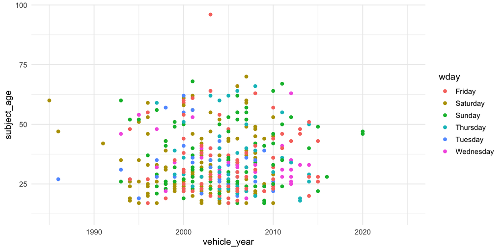

````markdown
```{r}
new_table |>
  drop_na(wday) |>
  ggplot(aes(x = vehicle_year, y = subject_age, color = wday)) +
  geom_point() +
  xlim(1985, 2025)
```
````

## Good practice

Always a good idea to terminate the **SQL** connection when you are done with it.

```r
dbDisconnect(con_traffic, shutdown = TRUE)
```